# Segregation and Contact, Measurement

## Learning Goals:

1. Describe how **segregation** may *moderate* the relationship between ethnic diversity and anti-minority attitudes
2. Explain and use the concept of a **scope condition**
3. Explain how diversity and segregation are often **measured** in empirical research
4. Recognize Modifiable Areal Unit Problems (MAUPs) and their consequences for research on contextual effects

## Questions about Laurence

1. According to Laurence, why should we expect to observe the prejudice only in communities that are both diverse **and** segregated?

**2x2**

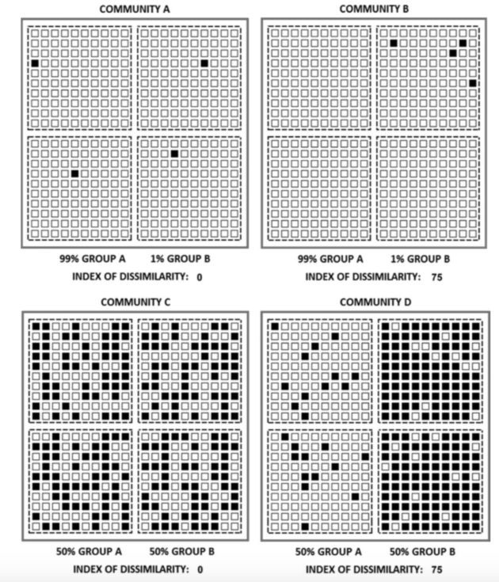

2. How can taking segregation into account help to reconcile the contact and conflict theories?

**Scope Conditions**

At one level, contact and conflict theories seem to make opposing predictions about the relationship between out-group size and prejudice.

However, in the social sciences, theoretical predictions rarely hold all of the time.

For instance, Laurence argues contact theory is more appropriate when segregation is low, and constrict theory is more approproriate when segregation is high.

The concept of segregation constitutes a **scope condition** – that is, it delimits the circumstances or the types of cases where a theory is supposed to apply.

While scope conditions may not be explicitly spelled out, they are (almost) alwas there, and we should be careful about extrapolating a theory beyond its scope conditions. By the same token, simply because a theory does not apply in all circumstances does not mean that the theory is “wrong.”

Take the following theoretical propositions and see if you can come up with some scope conditions:

- If you make something cheaper, more people will buy it.
- Politicians will adjust their positions towards the “median voter”.
- Pure liquid H<sub>2</sub>0 will turn to ice at 0 degrees celcius.

## Unpacking Laurence

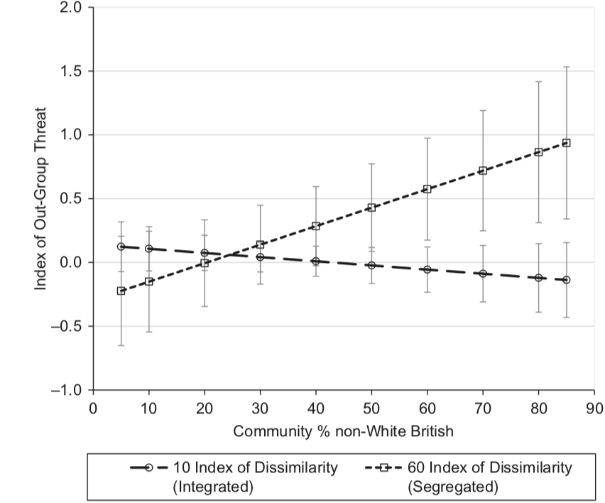

**A Quiz**

From the graph, which of the following statements is correct?

1. Diversity only affects prejudice in segregated communities.
2. Segregation only affects prejudice in highly-diverse communities
3. Both statements are correct.
4. Neither statement is correct.

### Measuring Diversity

Many researchers use an index of **Ethnolinguistic Fractionalization** (ELF) to measure diversity.

Imagine we had groups *g<sub>1</sub> , g<sub>2</sub> , g<sub>3</sub> , … g<sub>n</sub>*, where *g<sub>n</sub>* represents the percentage of individuals from group *n* in the population.

**ELF = 1 - ( *g<sub>1</sub>*<sup>2</sup> + *g<sub>2</sub>*<sup>2</sup> + *g<sub>3</sub>*<sup>2</sup> + … *g<sub>n</sub>*<sup>2</sup>** )

Note that ( *g<sub>1</sub>*<sup>2</sup> + *g<sub>2</sub>*<sup>2</sup> + *g<sub>3</sub>*<sup>2</sup> + … *g<sub>n</sub>*<sup>2</sup> ) = probability that two individuals will belong to the *same group*.

Thus, the ELF measures the probability that two randomly-selected will belong to *different groups*.

ELF ranges from 0 (completely homogenous) to 1 (every individual belongs to a unique group).

### Measurement Problem: “Color-Blindness”

Note that ELF treats all groups in a “color-blind” way. In other words, the following two neighborhoods are scored as equivalently diverse:

- **A:** 70% white, 30% black
- **B:** 30% white, 70% black

**Discussion**: do you think social relations would be similiar in these two areas? What’s missing from the “color-blind” view of groups?

**Small Groups**

Set aside for the moment the fact that **whites** living in segregated-diverse may be different than **whites** living in integrated-diverse areas.

1. In segregated areas: who are the **minorities** likely to be?
2. In integrated areas: who are the **minorities** likely to be?
3. How would you now interpret Laurence’s results?

### MAUP 1: The Problem of Scale

Note how diversity changes depending on whether we focus on the small vs. the large circles.

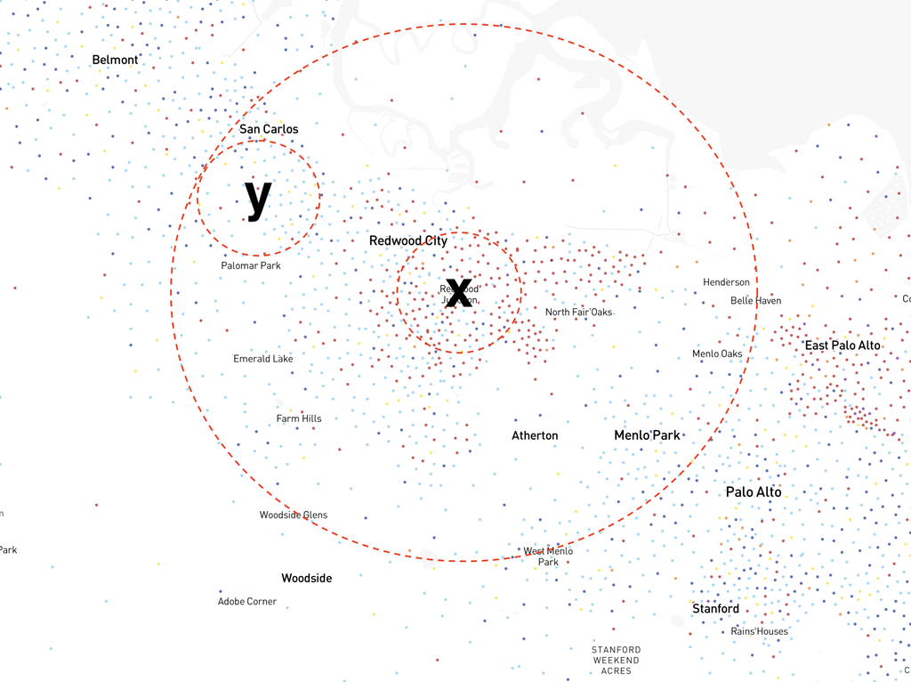

**Discussion:**

- What happens if the relevant contextual diversity is represented by the small circles, but we are only able to measure diversity within the larger circle?
- And what happens if the opposite were true? – That is, the relevant contextual diversity is represented by the large circle, but we measure diversity within the smaller circles instead?

More generally, a respondent could be placed within many avaiiable geographic units – e.g. neighborhood, city, county, metro area – but researchers don’t know which one is **contextually relevant**

### MAUP 2: Contextual Measures are Non-Spatial

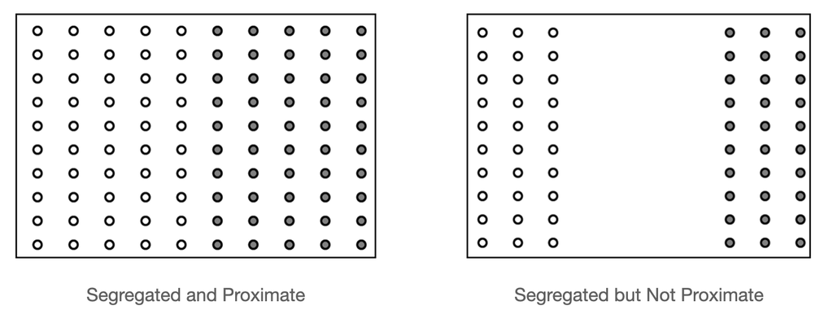

In the above figure, D might take on the same value, although we could expect that the psychological “effect” would be very different.

Do you think that non-spatiality would most likely lead us to over- or under-estimate the effect of segregation?

## Measuring Segregation: The Index of Dissimilarity (D)

*D* is one of the most commonly used measure of segregation between 2 groups. It compares their relative distribution across neighborhoods within the larger city.

**Formula**

$D = \frac{1}{2}\sum_{i=1}^{n} |\frac{a_{i}}{A} - \frac{b_{i}}{B}|$

- A = Total City Population of A
- B = Total City Population of B
- $a_{i}$ = Population of *a* in neighborhod *i*
- $b_{i}$ = Population of *b* in neighborhod *i*

*D* ranges from 0 to 100.

0 indicates conditions of total integration under which both groups are distributed in the same proportions across all neighborhoods.

100 indicates conditions of total segregation such that the members of one group are located in completely different neighborhoods than the second group.

Intuitively, *D* measures the percentage of one group that would have to move across neighborhoods to be distributed the same way as the second group.

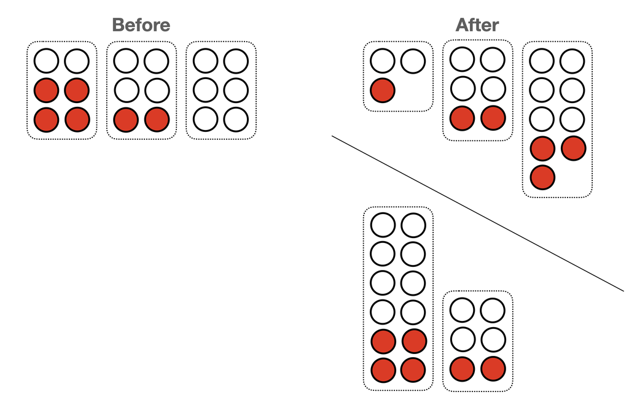

### MAUP 3: The Problem of Boundaries

Conceptually, segregation is about how groups are arranged in space.

However, *D* calculates segregation based on how groups are distributed across (arbitrarily drawn) administrative units.

What is *D* in each of the following units?

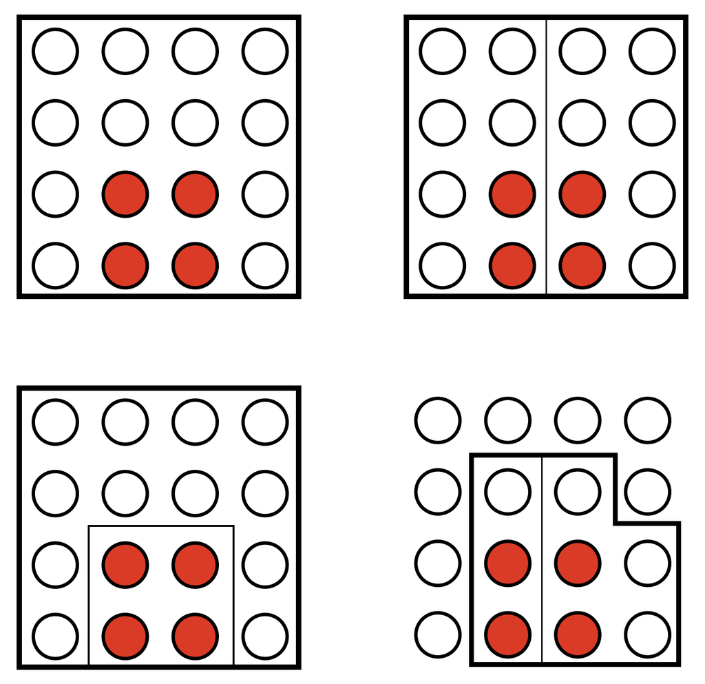

## Questions about Enos

1. What does Enos’s study demonstrate about the effect of segregation on voting?
2. Why does Enos call this study a “natural experiment”? How is it different from the randomized experiment on train platforms?
3. Why is the MAUP not a problem in Enos’ study?

## Final food for thought:

Note that in Enos’ study, the “treatment” was the presence / absence of a population that was both poor and black. In fact, many segregated communities are both racially *and* economically marginalized. What does this suggest to you about the drivers of intergroup conflict?

More broadly, the readings for this week show that the presence of a segregated, poor, marginalized minority group tends to elicit group conflict. That’s not exactly surprising! But it’s a big step to go from that evidence to an argument about the general effects of diversity or segregation.

Here’s a couple of thought experiments:

1. How would whites’ prejudice change if their poor, black neighbors “on the other side of the tracks” were all of a sudden dispersed into white neighborhoods (i.e. segregation decreases, but diversity and the racial socioeconomic gap remains the same)?
2. How would whites’ prejudice change if – instead of living near a poor, black enclave – they found themselves living next to an enclave full of rich sheiks from Saudi Arabia?